# Making Figures Count

A guide to the figures and R code

Author

Aron Hill

Published

September 21, 2026

## Start here!

This guide follows the figures presented in the Research Incubator talk. Data from the same 80 simulated participants is used throughout, improving the first bar chart and exploring what each alternative reveals, before saving the final figures for e.g., use in a manuscript.

**Download the materials:** The R script, dataset and presentation slides are available in the [GitHub repository](https://github.com/aronthill/making-figures-count). Click the green **Code** button, then **Download ZIP**.

Extract the ZIP before opening the files. Keep the folder structure intact so the R script can find the data.

**To make the figures:** open the accompanying **Plot_walkthrough.R** file in RStudio and follow the instructions in the script. Set your working directory to the folder containing the script by choosing **Session → Set Working Directory → To Source File Location**. Keep the supplied folder structure intact so the script can find the data.

Some plots build on earlier plots, so work through the sections in order on your first run. Use **Ctrl+Enter** on Windows or **Cmd+Enter** on Mac to run selected lines. Alternatively, run the entire script with `source("Plot_walkthrough.R")`.

To display a plot again, type its object name, such as `p_boxpoints`, into the Console and press Enter.

## Data and setup

This example uses a ficticious study comparing placebo with 200 mg caffeine on a sustained-attention task. Vigilance scores run from 0 to 100, with higher values indicating better performance. There are 40 participants per group. **All scores are simulated**; (not actual participant data!)

The first three sections load packages, read the CSV and define shared settings. In R, `<-` assigns a value to an object and `|>` passes a result to the next step. In ggplot2, `aes()` maps data columns to visual features, `geom_` functions draw layers, and `+` adds another layer or setting. `geom_col()` uses supplied bar heights; `geom_bar()` counts rows by default.

### Load packages

*R script: section 1.*

The script checks for missing packages and installs only those. `ggplot2` draws the figures, `dplyr` calculates summaries, `ragg` saves PNGs.

**Show R code**

```r
# 1. Load packages
# -----------------------------------------------------------------------------

# Open this file in RStudio, then choose:
# Session > Set Working Directory > To Source File Location.
# Keep the code and data folders together. Run sections 1-3 first, then work
# down through the plots. Some later plots build on an earlier plot object.
# R 4.1 or later is needed for the |> symbol (the pipe).

# Install only packages that are not already available.
packages <- c("ggplot2", "dplyr", "ragg")
missing_packages <- packages[!vapply(packages, requireNamespace,
                                    logical(1), quietly = TRUE)]
if (length(missing_packages) > 0) {
  install.packages(missing_packages, repos = "https://cloud.r-project.org")
}

library(ggplot2)    # Draw the plots.
library(dplyr)      # Summarise the data for each group.
library(ragg)       # Save clear PNG images.
```

### Read the data and summaries

*R script: section 2.*

`dat` holds the participant rows. `summ` is a separate table with one row per group. `sd` describes the spread of scores; `se` describes the estimated precision of the mean. `ci` is the **half-width** of a 95% t confidence interval, so its endpoints are `mean - ci` and `mean + ci`. These columns are calculated here before the plotting code uses them.

**Show R code**

```r
# 2. Read the data and calculate the summaries
# -----------------------------------------------------------------------------

# Each row is one participant. These are simulated data only!
# group identifies treatment; vigilance is a score on a 0-100 scale.

if (!file.exists("../data/caffeine_attention.csv")) {
  stop("Cannot find the CSV. Set the working directory to the code folder.")
}
dat <- read.csv("../data/caffeine_attention.csv")

# Put placebo first so the group order stays the same throughout.
dat <- dat |>
  mutate(group = factor(group, levels = c("Placebo", "Caffeine 200 mg")),
         xnum = as.numeric(group))


# Create a summary table from the data - this is needed for the bar plots
# -----------------------------------------------------------------------

# summ is a new table with one row per group.
# n: number of participants; mean: average score; sd: standard deviation.
# se: standard error of the mean (SD / square root of n).
# ci: half-width of a 95% t confidence interval, so its ends are mean +/- ci.
summ <- dat |>
  group_by(group) |>
  summarise(n = n(),
            mean = mean(vigilance),
            sd = sd(vigilance),
            se = sd / sqrt(n),
            ci = qt(0.975, n - 1) * se,
            .groups = "drop")

print(summ)
```

### Set colours and labels

*R script: section 3.*

Named colours keep the groups consistent across figures. Labels take their sample sizes from `summ`. Adding `style` to a plot reuses the colours, labels and theme. `theme_paper` sets larger text and light gridlines for the final figures. Try changing one setting at a time.

**Show R code**

```r
# 3. Set colours, labels and text sizes
# -----------------------------------------------------------------------------

# These settings are reused throughout. Edit the colours here rather than
# changing them separately in every figure. Group sizes come from summ.
pal <- c("Placebo" = "#4B77A8", "Caffeine 200 mg" = "#D98C1F")
group_labels <- setNames(paste0(summ$group, "\n(n = ", summ$n, ")"), summ$group)


# A list lets us add the same colours, labels and theme with + style.
# Change base_size to adjust the text, or remove selected gridlines below.
style <- list(
  scale_fill_manual(values = pal, guide = "none"),
  scale_colour_manual(values = pal, guide = "none"),
  scale_x_discrete(labels = group_labels),
  labs(x = NULL, y = "Vigilance score (0-100)"),
  theme_minimal(base_size = 14, base_family = "sans"),
  theme(panel.grid.minor = element_blank(),
        panel.grid.major.x = element_blank(),
        plot.margin = margin(10, 12, 10, 10))
)

# This theme is used for the compact violin and refined raincloud.
# Text is sized for a 160 x 125 mm figure. Check it at the final printed size.
theme_paper <- theme_minimal(base_size = 15, base_family = "sans") +
  theme(axis.title.y = element_text(size = 15, margin = margin(r = 10)),
        axis.text = element_text(size = 13, colour = "grey15"),
        axis.title.x = element_blank(),
        panel.grid.minor = element_blank(),
        panel.grid.major.x = element_blank(),
        panel.grid.major.y = element_line(colour = "grey91", linewidth = 0.3),
        plot.margin = margin(10, 12, 8, 8))


# Now with housekeeping out of the way, we can start to create the plots!
```

## The first draft

*R script: section 4.*

The bars show means with ±1 standard error, but the figure itself does not explain the error bars. Small labels and vague axis titles make it harder to read. Most importantly, two averages hide the participant scores and the shape of each distribution.

**Look for:** what would you need to know before interpreting these bars?

**Show R code**

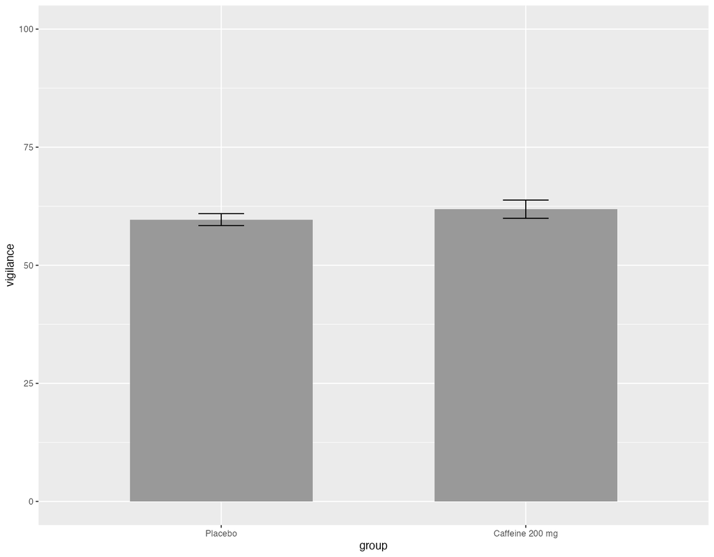

Group means and ±1 standard error. Synthetic vigilance scores, n = 40 per group.

```r
# 4. The first bar chart
# -----------------------------------------------------------------------------

# Simple initial bar plot
p_first <- ggplot(summ,
  aes(group, mean)) +
  geom_col(fill = "grey60", width = 0.6) +
  geom_errorbar(aes(
    ymin = mean - se,
    ymax = mean + se), width = 0.15) +
  labs(x = "group", y = "vigilance") +
  scale_y_continuous(limits = c(0, 100)) +
  theme_grey(base_size = 7)

print(p_first)
```

**Show R code**

```r
# Optional - save out figure
# --------------------------

# Currently, I have not added saving options for these initial plots. However,
# if you want to save out the figure you can uncomment this section below
# (to uncomment, highlight the text and press Command + Shif +C [Mac]).

# # Create the output folder if it does not already exist.
# fig_dir <- "saved_figures"
# dir.create(fig_dir, showWarnings = FALSE)
#
# # Save the first bar chart as a PNG.
# ggsave(
#   filename = file.path(fig_dir, "first_bar_chart.png"),
#   plot = p_first,
#   width = 160,
#   height = 125,
#   units = "mm",
#   dpi = 320,
#   device = ragg::agg_png,
#   bg = "white"
# )
```

## Clearer labels and confidence intervals

*R script: section 5.*

This version adds readable labels, group colours and sample sizes. It also replaces SE bars with **95% confidence intervals**.

**Show R code**

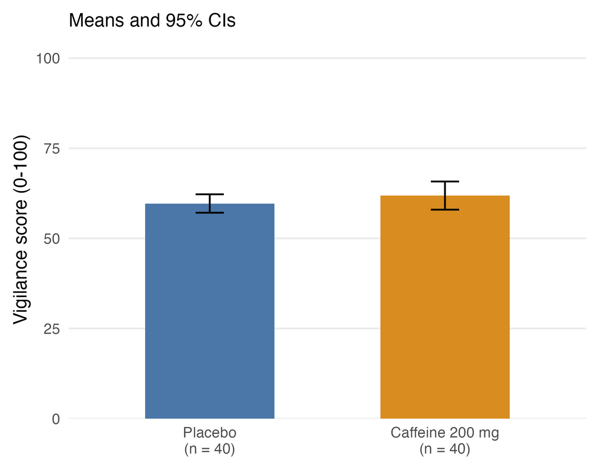

Group means and 95% t confidence intervals. Synthetic data, n = 40 per group.

```r
# 5. Create again with clearer labels and confidence intervals
# -----------------------------------------------------------------------------

# Use colour and readable labels, and show the group sample sizes.
# Changing SE to 95% CIs changes the information as well as the appearance.
# geom_col uses the means already calculated in summ.
p_bar <- ggplot(summ,
  aes(group, mean, fill = group)) +
  geom_col(width = 0.55) +
  geom_errorbar(aes(
    ymin = mean - ci,
    ymax = mean + ci), width = 0.12) +
  style +
  labs(subtitle = "Means and 95% CIs") +
  scale_y_continuous(
    limits = c(0, 100),
    expand = expansion(mult = c(0, 0.05)))

print(p_bar)
```

## Boxplots

*R script: section 7.*

A boxplot shows the median and middle 50% of the scores. Whiskers extend to observed scores within 1.5 × IQR of the box hinges; observations beyond them appear separately. Such points are not automatically errors.

The summary is useful, but a boxplot still hides detailed distribution shape. Quite different distributions can produce similar boxes. Try `width` or `alpha` to adjust the appearance.

**Show R code**

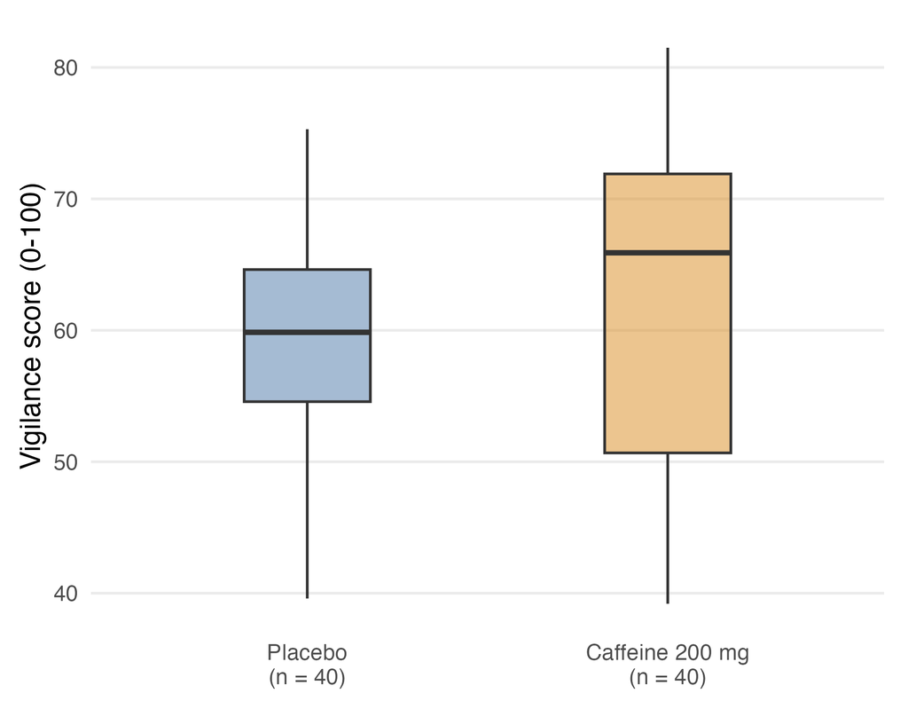

Medians, interquartile ranges and whiskers to observations within the 1.5 × IQR fences.

```r
# 7. Boxplots
# -----------------------------------------------------------------------------

# Use the individual scores in the dat variable. The box shows the median and middle 50%.
# Whiskers reach observations within 1.5 x IQR of the box hinges.
# Try changing width or alpha (0 = transparent, 1 = opaque).
p_box <- ggplot(dat,
  aes(group, vigilance, fill = group)) +
  geom_boxplot(width = 0.35,
    alpha = 0.5) +
  style

print(p_box)
```

## Histograms

*R script: section 8.*

Histograms can sometimes be usedul to get a feel for the distribution of the data.

Histograms can reveal spread, asymmetry, gaps and more than one concentration of observations.

The caffeine sample appears to have two concentrations of scores. Try `binwidth = 2` and `8` before interpreting the apparent peaks: the chosen bins affect what you see.

**Show R code**

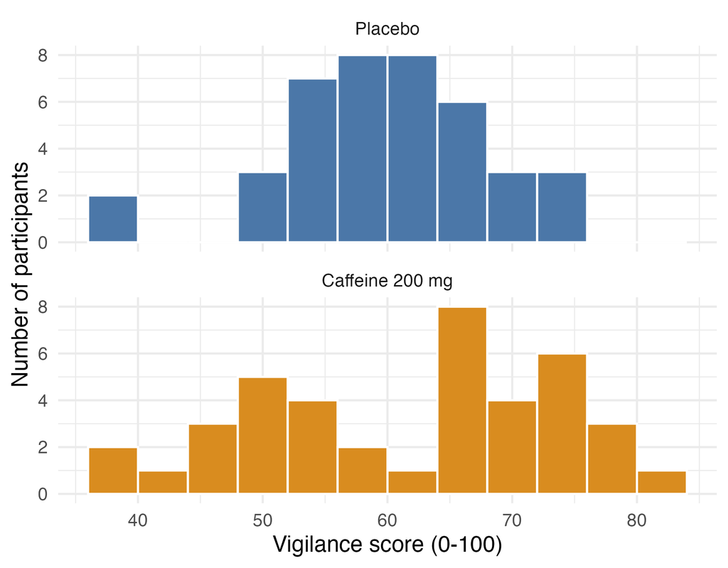

Participant counts in 4-point bins with a boundary at zero and shared axes. Synthetic data, n = 40 per group.

```r
# 8. Histograms
# -----------------------------------------------------------------------------

# Create a simple histogram for each group
p_hist <- ggplot(dat,
  aes(vigilance, fill = group)) +
  geom_histogram(binwidth = 4,
    boundary = 0, colour = "white") +
  facet_wrap(~ group, ncol = 1) +
  scale_fill_manual(values = pal,
    guide = "none") +
  labs(x = "Vigilance score (0-100)",
    y = "Number of participants") +
  theme_minimal(base_size = 14)

print(p_hist)
```

## Density plots

*R script: section 9.*

A density curve gives a smooth estimate of distribution shape. Its height is **density**, not a participant count. Each group’s full estimated density has area one. The small marks underneath are a *rug*: one mark per observation.

The caffeine curve has two broad peaks at this smoothing setting. Try `adjust = 0.75` and `1.5`: stronger smoothing can merge the peaks. Compare the curve with the histogram and raw observations. This sample alone does not establish two distinct population subgroups.

**Show R code**

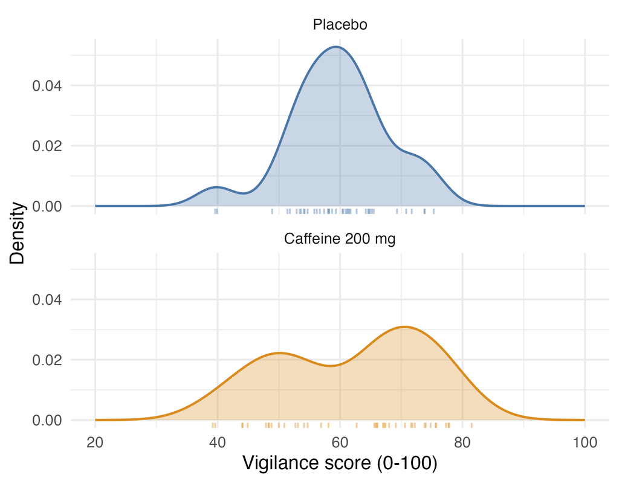

Kernel density estimates with adjust = 1. Rug marks show individual scores. Synthetic data, n = 40 per group.

```r
# 9. Density plots
# -----------------------------------------------------------------------------

# Similar to historgram, but with added smoothing.
p_density <- ggplot(dat,
  aes(vigilance, fill = group,
    colour = group)) +
  geom_density(adjust = 1, alpha = 0.3,
    linewidth = 0.8) +
  # Rug marks make the observed scores visible below the smooth estimate.
  geom_rug(alpha = 0.4, sides = "b") +
  # Separate panels make it easier to compare shapes using common axes.
  facet_wrap(~ group, ncol = 1) +
  # Leave room for the density tails; this range includes all supplied scores.
  scale_x_continuous(limits = c(20, 100)) +
  scale_fill_manual(values = pal,
    guide = "none") +
  scale_colour_manual(values = pal,
    guide = "none") +
  labs(x = "Vigilance score (0-100)",
    y = "Density") +
  theme_minimal(base_size = 14)

print(p_density)
```

## Violin plots with a boxplot

*R script: section 10.*

A violin is basically just a mirrored density estimate (imagine a density plot flipped on its side!). Wider parts of the violin indicate greater estimated density at that score. Violin plots can show data distribution features that are not observable with a boxplot alone, while the box retains a familiar summary of the median and IQR.

`trim = TRUE` stops the violin at the observed range; `adjust` controls smoothing. These full violins use the default equal-area scaling, and both groups contain 40 observations.

**Show R code**

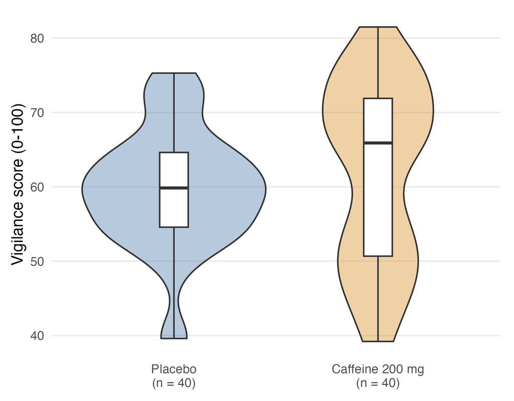

Violin densities with embedded boxplots. Smoothing adjustment = 0.8. Synthetic data, n = 40 per group.

```r
# 10. Violin plots with a boxplot
# -----------------------------------------------------------------------------

# Violin plots can be useful for showing data variability. Here, we'll plot
# a violin plot with a box-plot inside.

p_violin <- ggplot(dat,
  aes(group, vigilance, fill = group)) +
  geom_violin(trim = TRUE,
    adjust = 0.8, alpha = 0.4) +
  geom_boxplot(width = 0.14,
    fill = "white") +
  style

print(p_violin)
```

## A simpler violin plot

*R script: section 11.*

For a smaller figure, you could potentially replace the box with a median dot and two lines. The **white dot is the median**, the **thick line is the IQR**, and the **thin line is the observed minimum–maximum**. Neither line is a confidence interval. The thin line is different from a standard boxplot whisker.

The smooth shape remains visible, but individual observations are hidden. Use points as well when the individual scores matter to your question.

**Show R code**

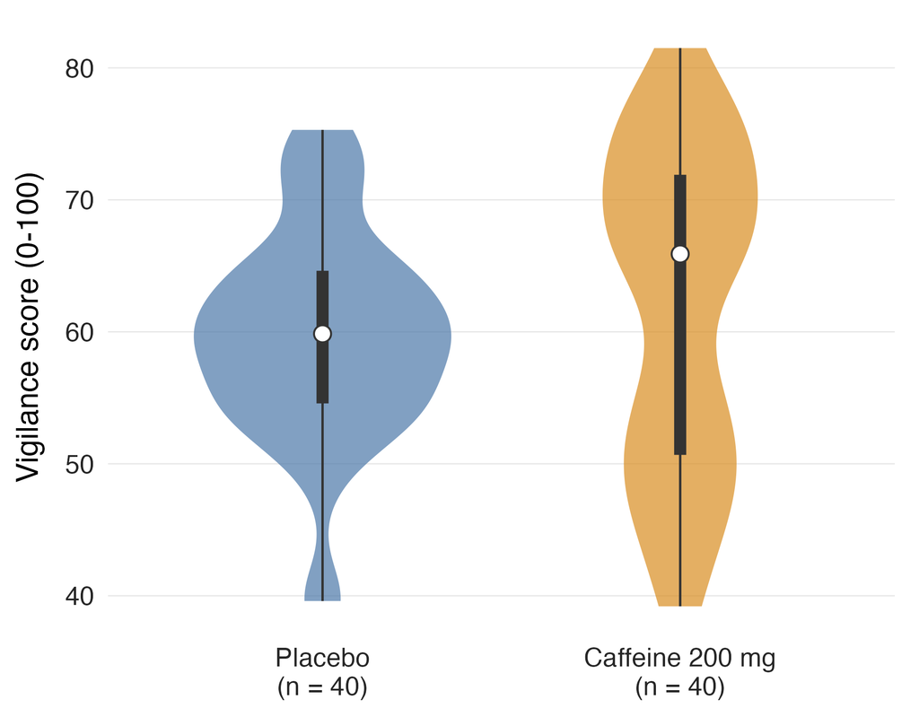

White dot: median. Thick line: IQR. Thin line: observed range. Smoothing adjustment = 0.8. Synthetic data, n = 40 per group.

```r
# 11. A simpler violin plot
# -----------------------------------------------------------------------------

# An alternative style violin plot. Here, the dot is the median, the thick dark
# line is the 50% of scores (from 25th - 75th percentile), the thin line is the
# lowest to highest scores.

violin_summary <- dat |>
  group_by(group) |>
  summarise(low = min(vigilance), high = max(vigilance),
            q1 = quantile(vigilance, 0.25),
            q3 = quantile(vigilance, 0.75),
            centre = median(vigilance), .groups = "drop")
violin_style <- list(
  scale_fill_manual(values = pal, guide = "none"),
  scale_x_discrete(labels = group_labels, expand = expansion(add = 0.6)),
  scale_y_continuous(breaks = seq(40, 80, 10)),
  labs(y = "Vigilance score (0-100)"),
  theme_paper
)


# Start with the full violin and overlay the range, IQR and median, in that
# order. colour = NA removes the violin outline. To show individual scores as
# well, use the raincloud or points-and-boxplot example.
p_compact <- ggplot(dat,
  aes(group, vigilance)) +
  geom_violin(aes(fill = group),
    width = 0.72, adjust = 0.8,
    alpha = 0.7, colour = NA) +
  # Thin line: the lowest to highest observed score.
  geom_linerange(data = violin_summary,
    aes(y = centre, ymin = low, ymax = high),
    linewidth = 0.55, colour = "grey20") +
  # Thick line: the middle 50% of scores.
  geom_linerange(data = violin_summary,
    aes(y = centre, ymin = q1, ymax = q3),
    linewidth = 2.8, colour = "grey20") +
  # White dot: the median. It is drawn last so the lines do not cover it.
  geom_point(data = violin_summary,
    aes(y = centre), shape = 21, size = 3.5,
    fill = "white", colour = "grey20") +
  violin_style

print(p_compact)
```

## Individual scores

*R script: section 12.*

Each point represents one participant. Horizontal jitter separates overlapping points while `height = 0` keeps every score unchanged. A fixed `seed` makes the layout repeatable.

Try changing the jitter width, point size or transparency. Too little jitter leaves overlap; too much can make group membership harder to follow.

**Show R code**

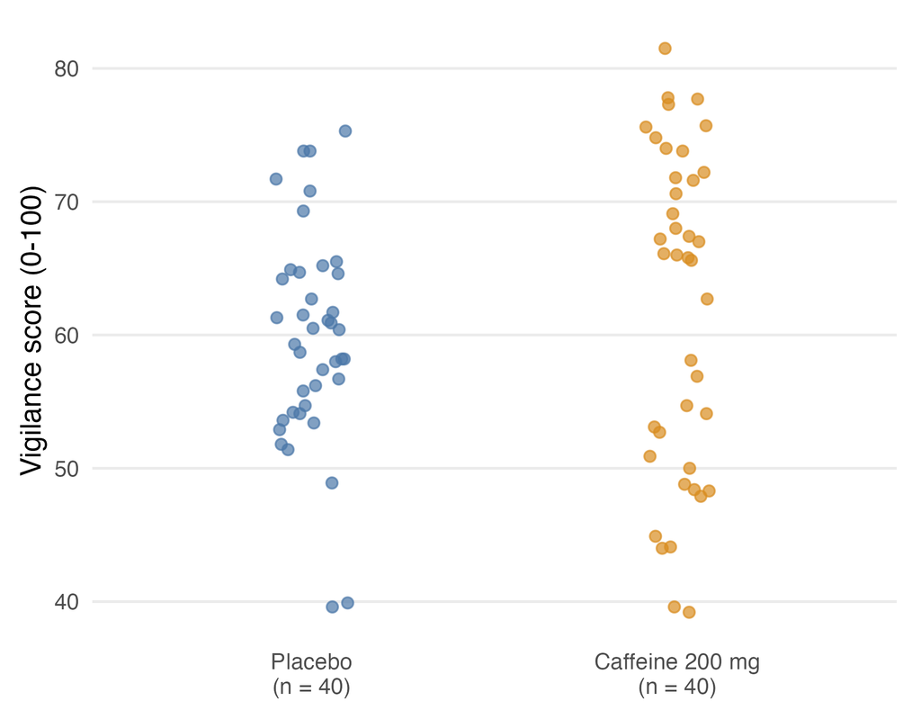

Individual scores with horizontal jitter only. Synthetic data, n = 40 per group.

```r
# 12. Individual scores
# -----------------------------------------------------------------------------

# Very simple jitter plot of individual scores. On its own this is not particularly
# informative, but it can be combined with other plots (e.g., box plot).

p_jitter <- ggplot(dat,
  aes(group, vigilance, colour = group)) +
  geom_point(size = 2.2, alpha = 0.7,
    position = position_jitter(
      width = 0.10, height = 0,
      seed = 1)) +
  style

print(p_jitter)
```

## Points with a boxplot

*R script: section 13.*

The points show every observation, while the box gives a concise summary. `outlier.shape = NA` suppresses duplicate outlier symbols from the boxplot because the point layer already includes those participants. **No observations are removed.**

This is already a useful manuscript option. A more elaborate plot is probably only worthwhile only if it further helps readers to decipher the data.

**Show R code**

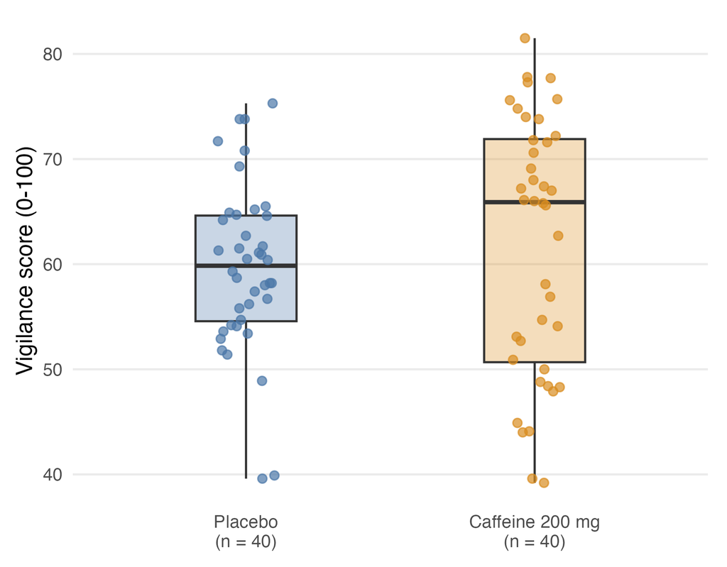

Individual scores, medians and IQRs. All participants are shown; duplicate boxplot outlier symbols are hidden.

```r
# 13. Points with a boxplot
# -----------------------------------------------------------------------------

# Box plot with jittered individual values overlaid.
p_boxpoints <- ggplot(dat,
  aes(group, vigilance)) +
  geom_boxplot(aes(fill = group),
    width = 0.35, alpha = 0.3,
    outlier.shape = NA) +
  geom_point(aes(colour = group),
    size = 2.2, alpha = 0.7,
    position = position_jitter(
      width = 0.10, height = 0, seed = 1)) +
  style

print(p_boxpoints)
```

## Raincloud plots

*R script: section 14.*

Raincloud plots combine elements of boxplots, violin plots, and individual data points. They are therefore useful for very transparently displaying your data.

The first part of this section calculates `cloud`. `density()` estimates a curve for each group and `geom_polygon()` draws one side of it. Each cloud is scaled to its **own maximum width**, so compare its shape rather than interpreting width as absolute density across groups. The box has an explicit group mapping because its x positions are numeric.

**Show R code**

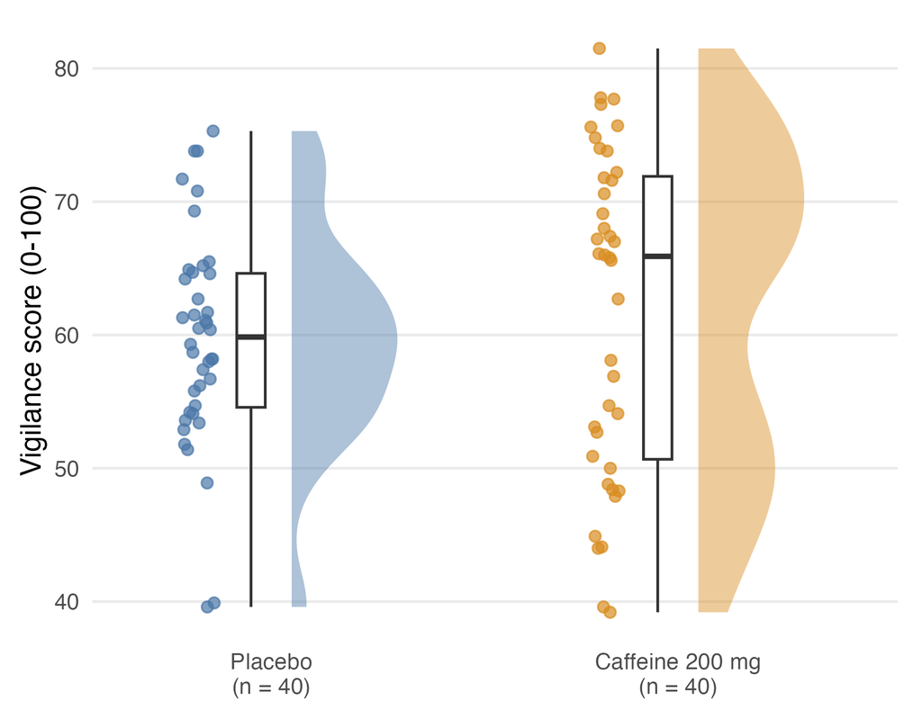

Individual scores, boxplots and half-violins. Each cloud is scaled to its own maximum width. Synthetic data, n = 40 per group.

```r
# 14. Raincloud plots
# -----------------------------------------------------------------------------

# Raincloud plots can be very useful as they convey a lot of data. They combine
# several plotting elements including individual data, a boxplot, and a violin
# plot all in one figure!

cloud <- dat |>
  group_by(group) |>
  group_modify(~ {
    d <- density(.x$vigilance, adjust = 0.8,
                 from = min(.x$vigilance), to = max(.x$vigilance))
    data.frame(score = c(d$x[1], d$x, tail(d$x, 1)),
               width = c(0, d$y / max(d$y), 0))
  }) |>
  ungroup() |>
  mutate(xnum = as.numeric(group))

# Numeric x positions (1 and 2) let us offset the layers horizontally.
# The offsets only control spacing; they have no scientific meaning.
rain_style <- list(
  scale_fill_manual(values = pal, guide = "none"),
  scale_colour_manual(values = pal, guide = "none"),
  scale_x_continuous(breaks = 1:2, labels = unname(group_labels),
                     limits = c(0.65, 2.45)),
  labs(x = NULL, y = "Vigilance score (0-100)"),
  theme_minimal(base_size = 14, base_family = "sans"),
  theme(panel.grid.minor = element_blank(),
        panel.grid.major.x = element_blank(),
        plot.margin = margin(10, 12, 10, 10))
)

p_rain <- ggplot() +
  geom_polygon(data = cloud, aes(
    xnum + 0.05 + width * 0.26, score,
    fill = group), alpha = 0.45) +
  geom_boxplot(data = dat, aes(
    xnum - 0.05, vigilance, group = group),
    width = 0.07, fill = "white",
    outlier.shape = NA) +
  geom_point(data = dat, aes(
    xnum - 0.18, vigilance, colour = group),
    size = 2.2, alpha = 0.7,
    position = position_jitter(
      width = 0.04, height = 0, seed = 1)) +
  rain_style

print(p_rain)
```

## Refining the raincloud

*R script: section 15.*

Keep the same data and density calculation, then increase label sizes, widen the boxes slightly, thicken their outlines and use larger filled points with white outlines. A little more horizontal jitter helps separate the points, while `height = 0` preserves their scores. Light gridlines help comparison without dominating the figure.

A simple caption could read: *Vigilance scores in the placebo and caffeine (200 mg) groups (n = 40 per group; simulated data). Points show individual participants, boxes show medians and interquartile ranges, and half-violins show the estimated distributions.*

**Show R code**

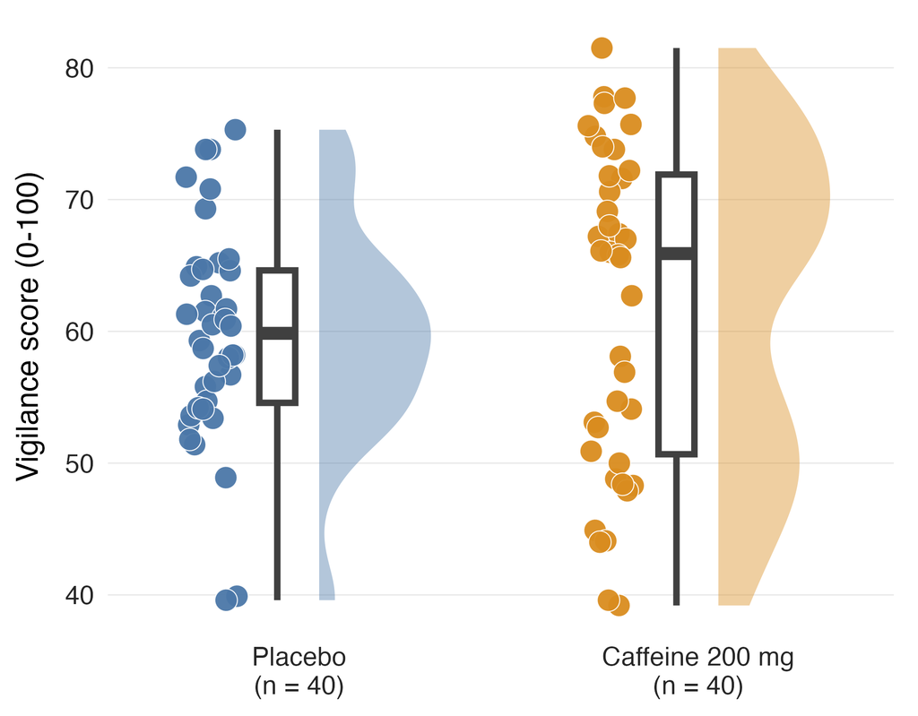

Refined raincloud with larger labels and points. The observations, boxplot summaries and density estimates are unchanged.

```r
# 15. Refine the raincloud
# -----------------------------------------------------------------------------

# We can do some tweaks here to refine the raincloud plot and perhaps make it
# a little nicers aesthetically (really just personal preference!)

# Try playing around with some of the options (e.g., line width, size for the
# geom_point dots etc) and re-draw to see changes.

rain_canvas <- ggplot() +
  geom_polygon(data = cloud,
    aes(xnum + 0.05 + width * 0.28, score, fill = group), alpha = 0.42) +
  scale_fill_manual(values = pal, guide = "none") +
  scale_x_continuous(breaks = 1:2, labels = unname(group_labels),
                     limits = c(0.61, 2.40)) +
  scale_y_continuous(breaks = seq(40, 80, 10)) +
  labs(y = "Vigilance score (0-100)")

p_polished <- rain_canvas +
  geom_boxplot(data = dat, aes(
    xnum - 0.055, vigilance, group = group),
    width = 0.09, fill = "white",
    colour = "grey25", linewidth = 1.5,
    outlier.shape = NA) +
  geom_point(data = dat, aes(
    xnum - 0.22, vigilance, fill = group),
    shape = 21, size = 5, stroke = 0.35,
    colour = "white", alpha = 0.95,
    position = position_jitter(
      width = 0.065, height = 0, seed = 1)) +
  theme_paper

print(p_polished)
```

## Export and final size

*R script: section 16.*

Set the physical dimensions before judging readability. Use the dimensions required for your manuscript. Increasing DPI improves resolution but does not enlarge the text.

Run the earlier sections first to create `p_polished` and `p_compact`. This section creates `saved_figures/` inside your working directory and saves four files: a PNG and PDF of the refined raincloud, and a PNG and PDF of the narrower violin. With the working directory set to the script’s location, this is `code/saved_figures/`. An existing folder is kept; saving again replaces files with the same names.

The first plots are displayed without being saved automatically. Section 4 includes a commented-out `ggsave()` example: uncomment it to save the first bar chart. Reuse that example for another plot by changing the plot object and filename.

Check labels, points and line widths after placing the exported figure in the manuscript. The smaller violin has its own text sizes and margins, rather than being a shrunken copy of the larger figure.

**Show R code**

```r
# 16. Save figures for a manuscript
# -----------------------------------------------------------------------------

# Run the earlier sections first to create p_polished and p_compact.


# A. Create a folder for the saved figures
# -----------------------------------------------------------------------------

# This creates saved_figures inside your current working directory.
# If the folder already exists, its contents are kept.
fig_dir <- "saved_figures"

dir.create(fig_dir, showWarnings = FALSE)



# B. Save the refined raincloud plot
# -----------------------------------------------------------------------------

# PNG is useful for slides. PDF keeps text and lines sharp when resized.

ggsave(
  filename = file.path(fig_dir, "raincloud_refined.png"),
  plot = p_polished,
  width = 160,
  height = 125,
  units = "mm",
  dpi = 320,
  device = ragg::agg_png,
  bg = "white"
)

# PDF is a vector format, so we don't need a DPI setting here.
ggsave(
  filename = file.path(fig_dir, "raincloud_refined.pdf"),
  plot = p_polished,
  width = 160,
  height = 125,
  units = "mm",
  bg = "white"
)


# C. Prepare and save a narrower violin plot
# -----------------------------------------------------------------------------

# Make a separate version for a 90 mm-wide figure.
# Adjust text sizes and margins for this smaller layout.
# The original p_compact plot stays unchanged.

p_compact_small <- p_compact +
  theme(
    axis.title.y = element_text(size = 11, margin = margin(r = 5)),
    axis.text = element_text(size = 10),
    plot.margin = margin(6, 5, 6, 5)
  )

# Display it before saving.
print(p_compact_small)
```

**Show R code**

```r
ggsave(
  filename = file.path(fig_dir, "violin_compact_90mm.png"),
  plot = p_compact_small,
  width = 90,
  height = 100,
  units = "mm",
  dpi = 320,
  device = ragg::agg_png,
  bg = "white"
)

ggsave(
  filename = file.path(fig_dir, "violin_compact_90mm.pdf"),
  plot = p_compact_small,
  width = 90,
  height = 100,
  units = "mm",
  bg = "white"
)
```